# Reproducible Research Assignment: Course Project 1

Pieter Eksteen

April 20, 2019

## Introduction

It is now possible to collect a large amount of data about personal movement using activity monitoring devices such as a Fitbit, Nike Fuelband, or Jawbone Up. These type of devices are part of the “quantified self” movement - a group of enthusiasts who take measurements about themselves regularly to improve their health, to find patterns in their behavior, or because they are tech geeks. But these data remain under-utilized both because the raw data are hard to obtain and there is a lack of statistical methods and software for processing and interpreting the data.

This assignment makes use of data from a personal activity monitoring device. This device collects data at 5 minute intervals through out the day. The data consists of two months of data from an anonymous individual collected during the months of October and November, 2012 and include the number of steps taken in 5 minute intervals each day.

The data for this assignment can be downloaded from the course web site:

- Dataset: [Activity monitoring data](https://d396qusza40orc.cloudfront.net/repdata%2Fdata%2Factivity.zip) [52K]

The variables included in this dataset are:

- **steps**: Number of steps taking in a 5-minute interval (missing values are coded as **NA**)
- **date**: The date on which the measurement was taken in YYYY-MM-DD format
- **interval**: Identifier for the 5-minute interval in which measurement was taken

The dataset is stored in a comma-separated-value (CSV) file and there are a total of 17,568 observations in this dataset.

## Question 1: Loading and preprocessing the data

The first step in order to analyse the data, is to load all necessary R packages as well as the dataset.

```r
knitr::opts_chunk$set(echo = TRUE,
                      fig.path = 'figure/')


library(here)
library(dplyr)
library(ggplot2)
library(DMwR)
library(RColorBrewer)

debug_mode <- FALSE

##--Load the data
activity_data_raw <- read.csv(here::here(file.path("data", "activity.csv")))
```

The second step is to identify which data contained in the dataset requires additional preparation/transformation. Checking the data for **NA`s** can also be done at this point.

Verifying the class of each column in the dataset is a good starting point. (Ensuring that date fields in particular are of the correct class is important for any analyses pivoted around dates, days, times etc.) We can identify the class of each column contained in the dataset using the `lapply` function:

```r
lapply(activity_data_raw, class)
```

```
## $steps
## [1] "integer"
##
## $date
## [1] "factor"
##
## $interval
## [1] "integer"
```

```r
colSums(is.na(activity_data_raw))
```

```
##    steps     date interval
##     2304        0        0
```

From the above result, we can see that the date field is of class `factor` and that the steps field contains **2304** NA`s.

We can now use the dplyr function `mutate` to convert the date field to class `Date` and the `na.omit` function to remove all rows containing NA`s from the dataset.

```r
##--Prepare data for analysis
activity_data <- activity_data_raw %>%
    ##--Convert date from factor to date format
    mutate(date = as.Date(date, "%Y-%m-%d")) %>%
    ##Remove NA`s
    na.omit()

lapply(activity_data, class)
```

```
## $steps
## [1] "integer"
##
## $date
## [1] "Date"
##
## $interval
## [1] "integer"
```

```r
colSums(is.na(activity_data))
```

```
##    steps     date interval
##        0        0        0
```

## Question 2: What is mean total number of steps taken per day?

In order to view the data per day, the dataset needs to be transformed to summarise steps per day:

```r
daily_data <- activity_data %>%
    select(-interval) %>%
    group_by(date) %>%
    summarise(daily_steps = sum(steps))
```

Now that we have a daily dataset, we can proceed to calculating the mean and median steps. We can also create a histogram of the total steps per day:

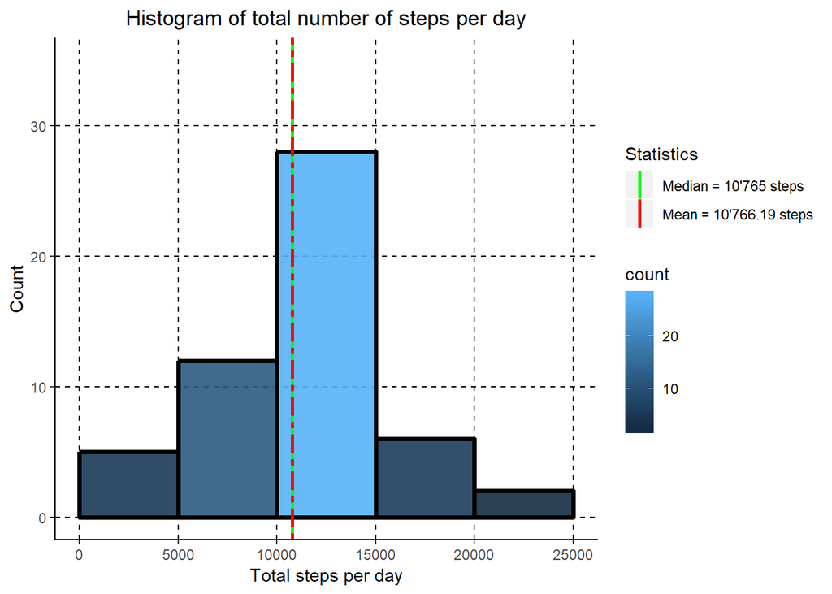

```r
##--Calculate mean and median of daily steps
daily_mean <- format(round(mean(daily_data$daily_steps), digits = 2), big.mark = "'")
daily_median <- format(round(median(daily_data$daily_steps), digits = 2), big.mark = "'")

##--Plot histogram
ggplot(daily_data, aes(daily_data$daily_steps)) +
    geom_histogram(aes(fill = ..count..),
                   breaks = c(seq(0, 25000, length.out = 6)),
                   col = "black",
                   size = 1.3,
                   alpha = 0.9) +
    ##--Add reference line for mean and median
    geom_vline(aes(xintercept = median(daily_data$daily_steps), colour = "green") ,
               linetype = "solid",
               size = 1) +
    geom_vline(aes(xintercept = mean(daily_data$daily_steps), colour = "red"),
               linetype = "twodash",
               size = 1) +
    labs(title = "Histogram of total number of steps per day") +
    xlab("Total steps per day") +
    ylab("Count") +
    ylim(0,35) +
    scale_color_manual(name = "Statistics",
                       values = c("green", "red"),
                       labels = c(paste("Median =", daily_median, "steps"),
                                  paste("Mean =", daily_mean, "steps"))) +
    theme(panel.grid.major = element_line(colour = "black", linetype = "dashed"),
          panel.grid.minor = element_blank(),
          panel.background = element_blank(),
          axis.line = element_line(colour = "black"),
          plot.title = element_text(hjust = 0.5))
```

The above histogram illustrates the total number of steps taken per day. The median number of steps taken per day is **10’765** and the mean number of steps taken per day is **10’766.19**

## Question 3: What is the average daily activity pattern?

To answer this question we need to summarise the data across all days to show the mean number of steps per 5-minute interval. After that we are able to calculate the interval containing the maximum mean steps and visualize all this data by constructing a time series plot:

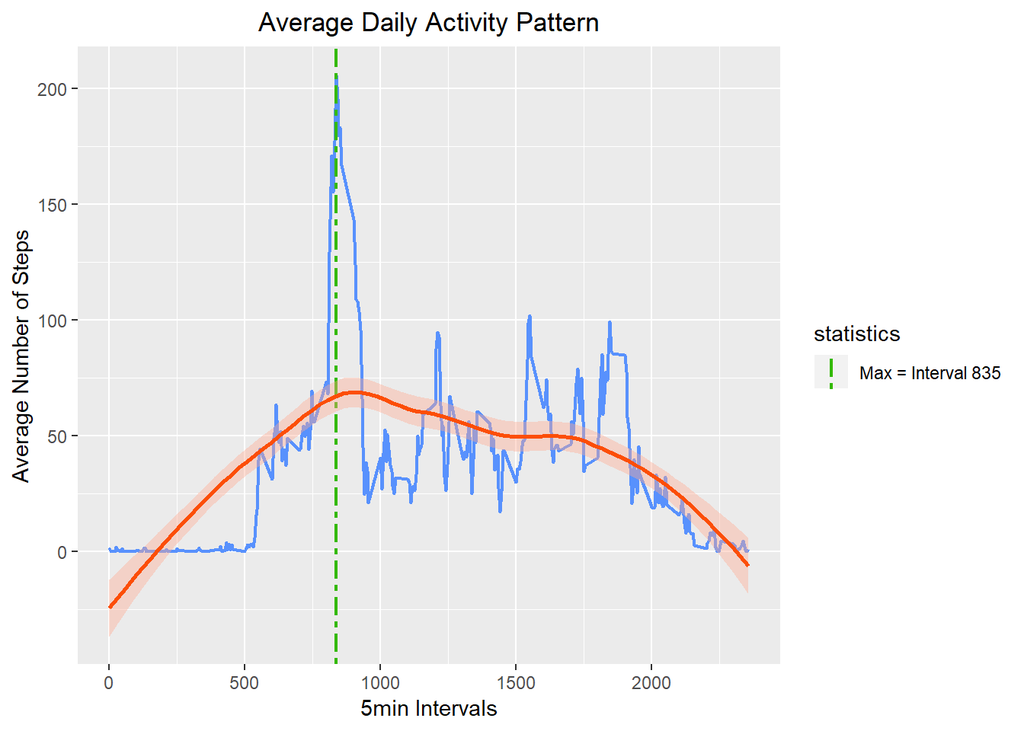

```r
##--Prepare data for analysis
interval_data <- activity_data %>%
    group_by(interval) %>%
    summarise(mean_steps = mean(steps))

##--Calculate the interval containing the maximum steps
max_steps_interval <- interval_data %>%
    filter(mean_steps == max(mean_steps)) %>%
    .$interval

# Plot average number of steps by 5-minute interval
ggplot(interval_data, aes(x = interval_data$interval, y = interval_data$mean_steps)) +
    geom_line(color = "#5891FD", size = 0.8) +
    geom_vline(aes(xintercept = max_steps_interval, colour = "#33B900"),
               linetype = "twodash",
               size = 0.8) +
    labs(title = "Average Daily Activity Pattern",
         y = "Average Number of Steps",
         x = "5min Intervals") +
    scale_color_manual(name = "statistics",
                       values = c("#33B900"),
                       labels = c(paste("Max = ", "Interval ", max_steps_interval, sep = ""))) +
stat_smooth(color = "#FC4E07",
            fill = "#FFAB91",
            method = "loess") +
theme(plot.title = element_text(hjust = 0.5))
```

The above time series plot shows the average number of steps taken per 5-minute interval across all days in the dataset.

From the plot we can see that the interval = **835** contains the maximum number of steps. This means that on average the maximum number of daily steps are taken between 8:35am and 8:40am.

## Question 4: Imputing missing values

Before we devise a strategy to deal with NA values in the dataset, let’s first analyse how many intervals within the dataset contain NA’s

```r
##--Check all columns for NA`s
colSums(is.na(activity_data_raw))
```

```
##    steps     date interval
##     2304        0        0
```

```r
##--Calculate total amount of rows in dataset
df_rows <- nrow(activity_data_raw)
print(paste("The data contains", format(df_rows, big.mark = "'"), "rows in total"))
```

```
## [1] "The data contains 17'568 rows in total"
```

```r
##--Calculate amount of rows conataining NA's
na_rows <- length(which(is.na(activity_data_raw)))
print(paste("The data contains", format(na_rows, big.mark = "'"), "rows with NA values"))
```

```
## [1] "The data contains 2'304 rows with NA values"
```

```r
##--Calculate percentage NA`s
percentage_na <- round(na_rows/df_rows*100, digits = 2)
print(paste(percentage_na, "% of the data is NA", sep = ""))
```

```
## [1] "13.11% of the data is NA"
```

From the above analysis, we see that **2’304** of the **17’568** rows contain NA’s.

Based on the fact that **13.11%** of the data is NA, I recommend using the k Nearest Neighbours method to replace the NA values with a weighted average of the k nearest neighbours (I have chosen to set k = 5% of the total days, this ensures that only the closest neighbours are used)

```r
daily_data_incl_NA <- activity_data %>%
    select(-interval) %>%
    group_by(date) %>%
    summarise(daily_steps = sum(steps))

##--Calculate 5% of total days to use as k-value
total_days <- as.numeric(length(daily_data_incl_NA$date))
k_value <- total_days*0.05

##--Use knn to predict NA`s with k = total days in dataset
imputed_activity_data <- knnImputation(activity_data_raw, k = k_value, meth = "weighAvg") %>%
    mutate(steps = round(steps, digits = 0))

##--Test to ensure no NA`s remain
if(length(which(is.na(imputed_activity_data))) == 0) {
    print("NA Replacement Successful")
} else {
    print(paste("ERROR: NA Replacement Unsuccessful,", length(which(is.na(imputed_activity_data))), "NA`s Remain"))
}
```

```
## [1] "NA Replacement Successful"
```

```r
if(debug_mode) {
    ##--Create df with NA and replacement values for visual comaparison
    original_steps <- activity_data %>%
        select(steps) %>%
        rename(original_steps = steps)

    compare_na_replace <- cbind(imputed_activity_data, original_steps) %>%
        select(date,
               interval,
               steps,
               original_steps)
}
```

We have now created a new dataset that is equal to the original dataset but with the missing data filled in. Using this new dataset we can make a histogram of the total number of steps taken each day and calculate and report the mean and median total number of steps taken per day.

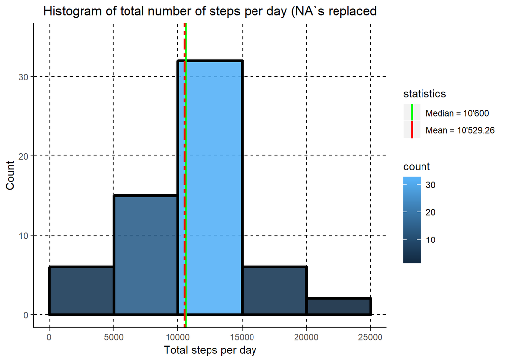

```r
##--Prepare data for analysis
imputed_daily_data <- imputed_activity_data %>%
    ##--Convert date from factor to date format
    mutate(date = as.Date(date, "%Y-%m-%d")) %>%
    select(-interval) %>%
    group_by(date) %>%
    summarise(daily_steps = sum(steps))

##--Calculate mean and median of daily steps
imputed_daily_mean <- format(round(mean(imputed_daily_data$daily_steps), digits = 2), big.mark = "'")
imputed_daily_median <- format(round(median(imputed_daily_data$daily_steps), digits = 2), big.mark = "'")

##--Plot histogram
ggplot(imputed_daily_data, aes(imputed_daily_data$daily_steps)) +
    geom_histogram(aes(fill = ..count..),
                   breaks = c(seq(0, 25000, length.out = 6)),
                   col = "black",
                   size = 1.3,
                   alpha = 0.9) +
    ##--Add reference line for mean and median
    geom_vline(aes(xintercept = median(imputed_daily_data$daily_steps), colour = "green") ,
               linetype = "solid",
               size = 1) +
    geom_vline(aes(xintercept = mean(imputed_daily_data$daily_steps), colour = "red"),
               linetype = "twodash",
               size = 1) +
    labs(title = "Histogram of total number of steps per day (NA`s replaced") +
    xlab("Total steps per day") +
    ylab("Count") +
    ylim(0,35) +
    scale_color_manual(name = "statistics",
                       values = c("green", "red"),
                       labels = c(paste("Median =", imputed_daily_median),
                                  paste("Mean =", imputed_daily_mean))) +
    theme(panel.grid.major = element_line(colour = "black", linetype = "dashed"),
          panel.grid.minor = element_blank(),
          panel.background = element_blank(),
          axis.line = element_line(colour = "black"),
          plot.title = element_text(hjust = 0.5))
```

The above histogram illustrates the total number of steps taken per day when the missing values are replaced using k Nearest Neighbours. With replaced NA values the median number of steps taken per day is **10’600** and the mean number of steps taken per day is **10’529.26**, compared to **10’765** and **10’766.19** respectively when the NA values are simply removed.

As we can see, both the median and the mean have reduced after missing values were imputed, which in my opinion is a more accurate representation. The reason for this is that omitting NA values will in most cases create bias, especially when examining the median and mean.

## Question 5: Are there differences in activity patterns between weekdays and weekends?

In order to analyse the differences in activity patterns between weekdays and weekends, we first need to create a variable to identify which dates are weekdays and which are weekends:

```r
imputed_activity_data <- imputed_activity_data %>%
    ##--Convert date from factor to date format
    mutate(date = as.Date(date, "%Y-%m-%d"),
           weekday_name = weekdays(date),
           type = ifelse(weekday_name %in% c("Saturday", "Sunday"),
                         "Weekend",
                         "Weekday") %>%
               factor(ordered = FALSE,
                      levels = c("Weekend",
                                 "Weekday")))
```

We can now eplore the differences between the weekday and weekend activity patterns using a panel plot containing time series plots for weekday and weekend activity:

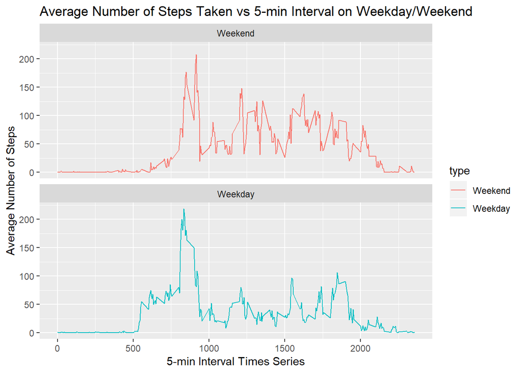

```r
daily_imputed_activity_data <- imputed_activity_data %>%
    group_by(interval, type) %>%
    summarise(mean_steps = mean(steps))

# Plot Average steps across weekday/weekend vs 5-min interval Time Series
ggplot(daily_imputed_activity_data, aes(x = interval, y = mean_steps, color = type)) +
    geom_line() +
    facet_wrap(~type, ncol = 1, nrow=2) +
    labs(title = "Average Number of Steps Taken vs 5-min Interval on Weekday/Weekend",
         y = "Average Number of Steps",
         x = "5-min Interval Times Series")
```